# Content-based filtering

Joe

still to do:

- does normalising the item vectors (rows) make any difference to cosine distance?

```r
library(tidyverse)
library(plotly)
library(knitr)
library(reshape2)
```

thoughts:

- need to down-weight product attributes that are very common
- Do I need to deal with products that have more attributes?
- note that this method will very likely want to give customers products that they’ve just bought before.

```r
product_data <-
  tibble( product_id = paste("product", 1:4, sep="_"),
          product_desc = c( "red, green, green, green",
                           " red, blue, green",
                           " blue, blue, blue",
                           "red, red, blue"
                           )
        ) %>%
  mutate(   tf_red = c( 1, 1, 0, 2),
           tf_blue = c( 0, 1, 2, 1 ),
          tf_green = c( 3, 1, 0, 0 ),
        ) %>%
  mutate( red_idf = log( 4 / 3 ),
          blue_idf = log( 4 / 3 ),
          green_idf = log( 4 / 2 )
        ) %>%
  mutate( red_tf_idf = tf_red * red_idf,
          blue_tf_idf = tf_blue * blue_idf,
          green_tf_idf = tf_green * green_idf
        )

product_data %>% kable()
```

| product_id | product_desc | tf_red | tf_blue | tf_green | red_idf | blue_idf | green_idf | red_tf_idf | blue_tf_idf | green_tf_idf |
| --- | --- | --- | --- | --- | --- | --- | --- | --- | --- | --- |
| product_1 | red, green, green, green | 1 | 0 | 3 | 0.2876821 | 0.2876821 | 0.6931472 | 0.2876821 | 0.0000000 | 2.0794415 |
| product_2 | red, blue, green | 1 | 1 | 1 | 0.2876821 | 0.2876821 | 0.6931472 | 0.2876821 | 0.2876821 | 0.6931472 |
| product_3 | blue, blue, blue | 0 | 2 | 0 | 0.2876821 | 0.2876821 | 0.6931472 | 0.0000000 | 0.5753641 | 0.0000000 |
| product_4 | red, red, blue | 2 | 1 | 0 | 0.2876821 | 0.2876821 | 0.6931472 | 0.5753641 | 0.2876821 | 0.0000000 |

```r
NA
```

plot the products in product space:

```r
product1_vector <- product_data[1,] %>%
                      select(red_tf_idf, blue_tf_idf, green_tf_idf) %>%
                      unlist()

product2_vector <- product_data[2,] %>%
                      select(red_tf_idf, blue_tf_idf, green_tf_idf) %>%
                      unlist()

product3_vector <- product_data[3,] %>%
                      select(red_tf_idf, blue_tf_idf, green_tf_idf) %>%
                      unlist()

product4_vector <- product_data[4,] %>%
                      select(red_tf_idf, blue_tf_idf, green_tf_idf) %>%
                      unlist()

plot_ly( data = product_data,
            x = ~red_tf_idf,
            y = ~blue_tf_idf,
            z = ~green_tf_idf
       ) %>%
  add_markers() %>%
  add_trace( type = "scatter3d",
             x = c( 0, product1_vector[1] ),
             y = c( 0, product1_vector[2] ),
             z = c( 0, product1_vector[3] ),
             mode = "lines",
             line = list(width = 4, color="blue")
            ) %>%
    add_trace( type = "scatter3d",
             x = c( 0, product2_vector[1] ),
             y = c( 0, product2_vector[2] ),
             z = c( 0, product2_vector[3] ),
             mode = "lines",
             line = list(width = 4, color="blue")
            ) %>%
    add_trace( type = "scatter3d",
             x = c( 0, product3_vector[1] ),
             y = c( 0, product3_vector[2] ),
             z = c( 0, product3_vector[3] ),
             mode = "lines",
             line = list(width = 4, color="blue")
            )  %>%
    add_trace( type = "scatter3d",
               x = c( 0, product4_vector[1] ),
               y = c( 0, product4_vector[2] ),
               z = c( 0, product4_vector[3] ),
               mode = "lines",
               line = list(width = 4, color="blue")
          )  %>%
  layout(scene = list( xaxis = list(title = 'red'),
                       yaxis = list(title = 'blue'),
                       zaxis = list(title = 'green')
                    )
       )
```

[interactive chart not shown]

Here is the product table for reference:

```r
product_data %>%
  select( product_id, red_tf_idf, blue_tf_idf, green_tf_idf )
```

| product_id | red_tf_idf | blue_tf_idf | green_tf_idf |
| --- | --- | --- | --- |
| product_1 | 0.2876821 | 0.0000000 | 2.0794415 |
| product_2 | 0.2876821 | 0.2876821 | 0.6931472 |
| product_3 | 0.0000000 | 0.5753641 | 0.0000000 |
| product_4 | 0.5753641 | 0.2876821 | 0.0000000 |

```r
customerA_profile <-
( 4*product3_vector + 2*product4_vector ) / 6

names( customerA_profile ) <- c( "red", "blue", "green" )

customerA_profile
```

```
      red      blue     green
0.1917880 0.4794701 0.0000000
```

We can now plot this customer in the product space:

```r
plot_ly( data = product_data,
            x = ~red_tf_idf,
            y = ~blue_tf_idf,
            z = ~green_tf_idf
       ) %>%
  add_markers() %>%
  add_trace( type = "scatter3d",
             x = c( 0, product1_vector[1] ),
             y = c( 0, product1_vector[2] ),
             z = c( 0, product1_vector[3] ),
             mode = "lines",
             line = list(width = 4, color="blue")
            ) %>%
    add_trace( type = "scatter3d",
             x = c( 0, product2_vector[1] ),
             y = c( 0, product2_vector[2] ),
             z = c( 0, product2_vector[3] ),
             mode = "lines",
             line = list(width = 4, color="blue")
            ) %>%
    add_trace( type = "scatter3d",
             x = c( 0, product3_vector[1] ),
             y = c( 0, product3_vector[2] ),
             z = c( 0, product3_vector[3] ),
             mode = "lines",
             line = list(width = 4, color="blue")
            )  %>%
    add_trace( type = "scatter3d",
             x = c( 0, product4_vector[1] ),
             y = c( 0, product4_vector[2] ),
             z = c( 0, product4_vector[3] ),
             mode = "lines",
             line = list(width = 4, color="blue")
            )  %>%
  layout(scene = list( xaxis = list(title = 'red'),
                       yaxis = list(title = 'blue'),
                       zaxis = list(title = 'green')
                    )
       ) %>%
  add_trace( type = "scatter3d",
             x = c( 0, customerA_profile[1] ),
             y = c( 0, customerA_profile[2] ),
             z = c( 0, customerA_profile[3] ),
             mode = "lines",
             line = list(width = 4, color="red")
            ) %>%
    add_trace( type = "scatter3d",
             x = c( 0, customerA_profile[1] ),
             y = c( 0, customerA_profile[2] ),
             z = c( 0, customerA_profile[3] ),
             mode = "points"
            )
```

[interactive chart not shown]

Here is a reminder of what customer $A$ bought:

```r
product_data %>%
  select( product_id, product_desc, red_tf_idf, blue_tf_idf, green_tf_idf ) %>%
  bind_cols( ., tibble(n_bought=c(0, 0, 4, 2) ) ) %>%
  select( product_id, product_desc, n_bought, everything() )
```

| product_id | product_desc | n_bought | red_tf_idf | blue_tf_idf | green_tf_idf |
| --- | --- | --- | --- | --- | --- |
| product_1 | red, green, green, green | 0 | 0.2876821 | 0.0000000 | 2.0794415 |
| product_2 | red, blue, green | 0 | 0.2876821 | 0.2876821 | 0.6931472 |
| product_3 | blue, blue, blue | 4 | 0.0000000 | 0.5753641 | 0.0000000 |
| product_4 | red, red, blue | 2 | 0.5753641 | 0.2876821 | 0.0000000 |

The angle $\theta$ between any 2 product vectors indicates their similarity. $cos(\theta)$ will therefore range as follows:

| $\theta$ | $cos(\theta)$ |
| --- | --- |
| $0^\circ$ | 1 |
| $30^\circ$ | 0.866 |
| $45^\circ$ | 0.707 |
| $60^\circ$ | 0.5 |
| $90^\circ$ | 0 |

The cosine of the angle between 2 vectors $\overset{\rightarrow{}}{u}$ and $\overset{\rightarrow{}}{u}$ can be calculated using

$$cos\Big(\theta_{uv}\Big) \quad=\quad \displaystyle\frac{u \cdot v}{|u| \space |v|}$$

Here are the angles between the product vectors in our example:

```r
cosine_distmat <- matrix( nrow = 4, ncol = 4 )

for( i in 1:4 ){
  for( j in 1:4 ){

    product_i <- product_data[i,] %>%
                      select(red_tf_idf, blue_tf_idf, green_tf_idf) %>%
                      unlist()
    product_j <- product_data[j,] %>%
                      select(red_tf_idf, blue_tf_idf, green_tf_idf) %>%
                      unlist()

    cos_theta <- ( product_i %*% product_j ) /
                 ( sqrt( sum(product_i^2) ) * sqrt( sum(product_j^2) ) )

    cosine_distmat[i,j] <- cos_theta
  }
}

rownames(cosine_distmat) <- colnames(cosine_distmat) <- paste("product", 1:4, sep="")

cosine_distmat %>% round(2)
```

```
         product1 product2 product3 product4
product1     1.00     0.90     0.00     0.12
product2     0.90     1.00     0.36     0.48
product3     0.00     0.36     1.00     0.45
product4     0.12     0.48     0.45     1.00
```

Here are the cosine distances between the customer and each product:

```r
cbind( product = 1:4,
       cos_dist_to_customerA =
       c(
          ( product1_vector %*% customerA_profile ) /
            ( sqrt( sum(product1_vector^2) ) * sqrt( sum(customerA_profile^2) ) )
          ,
          ( product2_vector %*% customerA_profile ) /
            ( sqrt( sum(product2_vector^2) ) * sqrt( sum(customerA_profile^2) ) )
          ,
          ( product3_vector %*% customerA_profile ) /
            ( sqrt( sum(product3_vector^2) ) * sqrt( sum(customerA_profile^2) ) )
          ,
          ( product4_vector %*% customerA_profile ) /
            ( sqrt( sum(product4_vector^2) ) * sqrt( sum(customerA_profile^2) ) )
       )
     )
```

```
     product cos_dist_to_customerA
[1,]       1             0.0508956
[2,]       2             0.4652689
[3,]       3             0.9284767
[4,]       4             0.7474093
```

So, if we needed to offer this customer a new product (choosing from either product_1 or product_2 which they haven’t bought yet), we’d offer them product_2.

# Higher-dimensional example

```r
generate_random_prod_ftn <- function(){

  product_vector <-
        tibble( formal=0, casual=0, sports=0,
                shoes=0, pants=0, shirt=0, tie=0, bag=0, socks=0,
                black=0, red=0, green=0, blue=0, white=0,
                stripes=0, bold=0, leopard_print=0, spots=0, shiny=0
              )

  choose_use <- sample( 1:3, size=1 )
  if( choose_use == 1 ){ product_vector$formal <- 1 } else
  if( choose_use == 2 ){ product_vector$casual <- 1 } else
                       { product_vector$sports <- 1 }

  choose_garment <- sample( 1:6, size=1 )
  if( choose_garment == 1 ){ product_vector$shoes <- 1 } else
  if( choose_garment == 2 ){ product_vector$pants <- 1 } else
  if( choose_garment == 3 ){ product_vector$shirt <- 1 } else
  if( choose_garment == 4 ){ product_vector$tie <- 1 } else
  if( choose_garment == 5 ){ product_vector$bag <- 1 } else
                           { product_vector$socks <- 1 }

  choose_colour <- sample( 1:5, size=1 )
  if( choose_colour == 1 ){ product_vector$black <- 1 } else
  if( choose_colour == 2 ){ product_vector$red <- 1 } else
  if( choose_colour == 3 ){ product_vector$green <- 1 } else
  if( choose_colour == 4 ){ product_vector$blue <- 1 } else
  { product_vector$white <- 1 }

  choose_style <- sample( 1:5, size=1 )
  if( choose_style == 1 ){ product_vector$stripes <- 1 } else
  if( choose_style == 2 ){ product_vector$bold <- 1 } else
  if( choose_style == 3 ){ product_vector$leopard_print <- 1 } else
  if( choose_style == 4 ){ product_vector$spots <- 1 } else
  { product_vector$shiny <- 1 }

  return( product_vector )
}

set.seed(1925)
full_product_list <-
  bind_rows(
    generate_random_prod_ftn(),
    generate_random_prod_ftn(),
    generate_random_prod_ftn(),
    generate_random_prod_ftn(),
    generate_random_prod_ftn(),
    generate_random_prod_ftn(),
    generate_random_prod_ftn(),
    generate_random_prod_ftn(),
    generate_random_prod_ftn(),
    generate_random_prod_ftn(),
    generate_random_prod_ftn(),
    generate_random_prod_ftn(),
    generate_random_prod_ftn(),
    generate_random_prod_ftn(),
    generate_random_prod_ftn(),
    generate_random_prod_ftn(),
    generate_random_prod_ftn(),
    generate_random_prod_ftn(),
    generate_random_prod_ftn(),
    generate_random_prod_ftn()
  ) %>%
  mutate( product_ID = row_number()
) %>%
  select( product_ID, everything() )

kable( full_product_list )
```

| product_ID | formal | casual | sports | shoes | pants | shirt | tie | bag | socks | black | red | green | blue | white | stripes | bold | leopard_print | spots | shiny |
| --- | --- | --- | --- | --- | --- | --- | --- | --- | --- | --- | --- | --- | --- | --- | --- | --- | --- | --- | --- |
| 1 | 1 | 0 | 0 | 0 | 1 | 0 | 0 | 0 | 0 | 1 | 0 | 0 | 0 | 0 | 0 | 0 | 0 | 1 | 0 |
| 2 | 0 | 1 | 0 | 0 | 0 | 0 | 0 | 1 | 0 | 0 | 1 | 0 | 0 | 0 | 1 | 0 | 0 | 0 | 0 |
| 3 | 1 | 0 | 0 | 0 | 1 | 0 | 0 | 0 | 0 | 0 | 0 | 0 | 0 | 1 | 0 | 0 | 1 | 0 | 0 |
| 4 | 1 | 0 | 0 | 1 | 0 | 0 | 0 | 0 | 0 | 0 | 1 | 0 | 0 | 0 | 0 | 0 | 1 | 0 | 0 |
| 5 | 0 | 1 | 0 | 0 | 0 | 0 | 1 | 0 | 0 | 1 | 0 | 0 | 0 | 0 | 0 | 0 | 1 | 0 | 0 |
| 6 | 0 | 0 | 1 | 0 | 0 | 0 | 0 | 1 | 0 | 0 | 0 | 0 | 1 | 0 | 1 | 0 | 0 | 0 | 0 |
| 7 | 0 | 0 | 1 | 0 | 0 | 1 | 0 | 0 | 0 | 1 | 0 | 0 | 0 | 0 | 0 | 1 | 0 | 0 | 0 |
| 8 | 0 | 0 | 1 | 0 | 0 | 0 | 1 | 0 | 0 | 0 | 0 | 1 | 0 | 0 | 1 | 0 | 0 | 0 | 0 |
| 9 | 0 | 1 | 0 | 1 | 0 | 0 | 0 | 0 | 0 | 0 | 0 | 0 | 1 | 0 | 0 | 1 | 0 | 0 | 0 |
| 10 | 0 | 0 | 1 | 0 | 0 | 0 | 1 | 0 | 0 | 0 | 0 | 0 | 1 | 0 | 0 | 1 | 0 | 0 | 0 |
| 11 | 0 | 0 | 1 | 0 | 0 | 0 | 0 | 1 | 0 | 0 | 0 | 1 | 0 | 0 | 0 | 0 | 1 | 0 | 0 |
| 12 | 0 | 0 | 1 | 0 | 0 | 0 | 1 | 0 | 0 | 0 | 0 | 0 | 1 | 0 | 0 | 1 | 0 | 0 | 0 |
| 13 | 1 | 0 | 0 | 0 | 0 | 0 | 1 | 0 | 0 | 0 | 0 | 1 | 0 | 0 | 0 | 0 | 1 | 0 | 0 |
| 14 | 0 | 1 | 0 | 0 | 0 | 1 | 0 | 0 | 0 | 0 | 1 | 0 | 0 | 0 | 0 | 0 | 1 | 0 | 0 |
| 15 | 1 | 0 | 0 | 0 | 0 | 0 | 0 | 1 | 0 | 0 | 0 | 0 | 1 | 0 | 0 | 1 | 0 | 0 | 0 |
| 16 | 1 | 0 | 0 | 0 | 1 | 0 | 0 | 0 | 0 | 0 | 0 | 1 | 0 | 0 | 0 | 0 | 1 | 0 | 0 |
| 17 | 0 | 1 | 0 | 0 | 0 | 0 | 0 | 0 | 1 | 0 | 0 | 0 | 0 | 1 | 0 | 0 | 1 | 0 | 0 |
| 18 | 1 | 0 | 0 | 0 | 0 | 0 | 1 | 0 | 0 | 0 | 0 | 0 | 0 | 1 | 0 | 0 | 0 | 1 | 0 |
| 19 | 0 | 0 | 1 | 0 | 0 | 1 | 0 | 0 | 0 | 0 | 1 | 0 | 0 | 0 | 0 | 1 | 0 | 0 | 0 |
| 20 | 1 | 0 | 0 | 0 | 0 | 1 | 0 | 0 | 0 | 0 | 0 | 0 | 1 | 0 | 0 | 0 | 0 | 0 | 1 |

get item/product profiles (tf-idf) for full product list:

```r
product_colsums <- full_product_list %>% select(-product_ID) %>% colSums()
product_IDFs <- log( nrow(full_product_list) / product_colsums )

cbind( count = t( t(product_colsums) ),
       IDF = t( t(product_IDFs) )
     )
```

```
              [,1]      [,2]
formal           8 0.9162907
casual           5 1.3862944
sports           7 1.0498221
shoes            2 2.3025851
pants            3 1.8971200
shirt            4 1.6094379
tie              6 1.2039728
bag              4 1.6094379
socks            1 2.9957323
black            3 1.8971200
red              4 1.6094379
green            4 1.6094379
blue             6 1.2039728
white            3 1.8971200
stripes          3 1.8971200
bold             6 1.2039728
leopard_print    8 0.9162907
spots            2 2.3025851
shiny            1 2.9957323
```

```r
product_IDFs_mat <- matrix( rep(product_IDFs, nrow(full_product_list)),
                            byrow = TRUE,
                            nrow = nrow(full_product_list)
                          )

product_profiles <- full_product_list * cbind( 1, product_IDFs_mat )
```

Customer A buys the following:

```r
# customer A likes formal and sports stuff
# and he like shoes and socks a lot
# and he like black and white a lot
# and he likes shiny leopard print things

customerA_product_probs <-
  full_product_list %>%
    mutate( prob_this_product =
              formal*10 + casual*1 + sports*10 +
              shoes*10 + pants*1 + shirt*1 + tie*1 + bag*4 + socks*10 +
              black*10 + red*2 + green*2 + blue*2 + white*10 +
              stripes*1 + bold*3 + leopard_print*10 + spots*2 + shiny*10
          ) %>%
  pull( prob_this_product )

set.seed(6969420)
customerA_products_chosen <-
  full_product_list[sample(1:nrow(full_product_list),prob=customerA_product_probs,size=5, replace=TRUE),]

customerA_products_chosen
```

| product_ID | formal | casual | sports | shoes | pants | shirt | tie | bag | socks | black | red | green | blue | white | stripes | bold | leopard_print | spots | shiny |
| --- | --- | --- | --- | --- | --- | --- | --- | --- | --- | --- | --- | --- | --- | --- | --- | --- | --- | --- | --- |
| 17 | 0 | 1 | 0 | 0 | 0 | 0 | 0 | 0 | 1 | 0 | 0 | 0 | 0 | 1 | 0 | 0 | 1 | 0 | 0 |
| 1 | 1 | 0 | 0 | 0 | 1 | 0 | 0 | 0 | 0 | 1 | 0 | 0 | 0 | 0 | 0 | 0 | 0 | 1 | 0 |
| 5 | 0 | 1 | 0 | 0 | 0 | 0 | 1 | 0 | 0 | 1 | 0 | 0 | 0 | 0 | 0 | 0 | 1 | 0 | 0 |
| 3 | 1 | 0 | 0 | 0 | 1 | 0 | 0 | 0 | 0 | 0 | 0 | 0 | 0 | 1 | 0 | 0 | 1 | 0 | 0 |
| 17 | 0 | 1 | 0 | 0 | 0 | 0 | 0 | 0 | 1 | 0 | 0 | 0 | 0 | 1 | 0 | 0 | 1 | 0 | 0 |

```r
customer_profile_vector <-
  customerA_products_chosen %>%
    select( product_ID ) %>%
    left_join( product_profiles ) %>%
    select( -product_ID ) %>%
    summarise_all( mean ) %>%
    unlist()
cosine_distances <- rep( NA, nrow(full_product_list) )
names(cosine_distances) <- paste("product", 1:nrow(full_product_list), sep="")

for( prod_i in 1:nrow(full_product_list) ){

  product_vector <- product_profiles[prod_i,-1] %>% unlist()

  cosine_distances[prod_i] <-
                 ( product_vector %*% customer_profile_vector ) /
                 ( sqrt( sum(product_vector^2) ) * sqrt( sum(customer_profile_vector^2) ) )
}
```

So, to recap, the customer bought:

```r
customerA_products_chosen
```

| product_ID | formal | casual | sports | shoes | pants | shirt | tie | bag | socks | black | red | green | blue | white | stripes | bold | leopard_print | spots | shiny |
| --- | --- | --- | --- | --- | --- | --- | --- | --- | --- | --- | --- | --- | --- | --- | --- | --- | --- | --- | --- |
| 17 | 0 | 1 | 0 | 0 | 0 | 0 | 0 | 0 | 1 | 0 | 0 | 0 | 0 | 1 | 0 | 0 | 1 | 0 | 0 |
| 1 | 1 | 0 | 0 | 0 | 1 | 0 | 0 | 0 | 0 | 1 | 0 | 0 | 0 | 0 | 0 | 0 | 0 | 1 | 0 |
| 5 | 0 | 1 | 0 | 0 | 0 | 0 | 1 | 0 | 0 | 1 | 0 | 0 | 0 | 0 | 0 | 0 | 1 | 0 | 0 |
| 3 | 1 | 0 | 0 | 0 | 1 | 0 | 0 | 0 | 0 | 0 | 0 | 0 | 0 | 1 | 0 | 0 | 1 | 0 | 0 |
| 17 | 0 | 1 | 0 | 0 | 0 | 0 | 0 | 0 | 1 | 0 | 0 | 0 | 0 | 1 | 0 | 0 | 1 | 0 | 0 |

and his top matched products are: ( the ones he’s already bought are obviously on top )

```r
bind_cols( full_product_list,
           tibble( cosine_dist = cosine_distances )
) %>%
  arrange( desc(cosine_dist) ) %>%
  kable()
```

| product_ID | formal | casual | sports | shoes | pants | shirt | tie | bag | socks | black | red | green | blue | white | stripes | bold | leopard_print | spots | shiny | cosine_dist |
| --- | --- | --- | --- | --- | --- | --- | --- | --- | --- | --- | --- | --- | --- | --- | --- | --- | --- | --- | --- | --- |
| 17 | 0 | 1 | 0 | 0 | 0 | 0 | 0 | 0 | 1 | 0 | 0 | 0 | 0 | 1 | 0 | 0 | 1 | 0 | 0 | 0.8234502 |
| 3 | 1 | 0 | 0 | 0 | 1 | 0 | 0 | 0 | 0 | 0 | 0 | 0 | 0 | 1 | 0 | 0 | 1 | 0 | 0 | 0.6582510 |
| 5 | 0 | 1 | 0 | 0 | 0 | 0 | 1 | 0 | 0 | 1 | 0 | 0 | 0 | 0 | 0 | 0 | 1 | 0 | 0 | 0.5414792 |
| 1 | 1 | 0 | 0 | 0 | 1 | 0 | 0 | 0 | 0 | 1 | 0 | 0 | 0 | 0 | 0 | 0 | 0 | 1 | 0 | 0.4983865 |
| 18 | 1 | 0 | 0 | 0 | 0 | 0 | 1 | 0 | 0 | 0 | 0 | 0 | 0 | 1 | 0 | 0 | 0 | 1 | 0 | 0.4894377 |
| 16 | 1 | 0 | 0 | 0 | 1 | 0 | 0 | 0 | 0 | 0 | 0 | 1 | 0 | 0 | 0 | 0 | 1 | 0 | 0 | 0.3714197 |
| 14 | 0 | 1 | 0 | 0 | 0 | 1 | 0 | 0 | 0 | 0 | 1 | 0 | 0 | 0 | 0 | 0 | 1 | 0 | 0 | 0.2756737 |
| 13 | 1 | 0 | 0 | 0 | 0 | 0 | 1 | 0 | 0 | 0 | 0 | 1 | 0 | 0 | 0 | 0 | 1 | 0 | 0 | 0.2309793 |
| 7 | 0 | 0 | 1 | 0 | 0 | 1 | 0 | 0 | 0 | 1 | 0 | 0 | 0 | 0 | 0 | 1 | 0 | 0 | 0 | 0.2073111 |
| 9 | 0 | 1 | 0 | 1 | 0 | 0 | 0 | 0 | 0 | 0 | 0 | 0 | 1 | 0 | 0 | 1 | 0 | 0 | 0 | 0.1543000 |
| 2 | 0 | 1 | 0 | 0 | 0 | 0 | 0 | 1 | 0 | 0 | 1 | 0 | 0 | 0 | 1 | 0 | 0 | 0 | 0 | 0.1500704 |
| 4 | 1 | 0 | 0 | 1 | 0 | 0 | 0 | 0 | 0 | 0 | 1 | 0 | 0 | 0 | 0 | 0 | 1 | 0 | 0 | 0.1386485 |
| 11 | 0 | 0 | 1 | 0 | 0 | 0 | 0 | 1 | 0 | 0 | 0 | 1 | 0 | 0 | 0 | 0 | 1 | 0 | 0 | 0.1071522 |
| 15 | 1 | 0 | 0 | 0 | 0 | 0 | 0 | 1 | 0 | 0 | 0 | 0 | 1 | 0 | 0 | 1 | 0 | 0 | 0 | 0.0568348 |
| 10 | 0 | 0 | 1 | 0 | 0 | 0 | 1 | 0 | 0 | 0 | 0 | 0 | 1 | 0 | 0 | 1 | 0 | 0 | 0 | 0.0528675 |
| 12 | 0 | 0 | 1 | 0 | 0 | 0 | 1 | 0 | 0 | 0 | 0 | 0 | 1 | 0 | 0 | 1 | 0 | 0 | 0 | 0.0528675 |
| 8 | 0 | 0 | 1 | 0 | 0 | 0 | 1 | 0 | 0 | 0 | 0 | 1 | 0 | 0 | 1 | 0 | 0 | 0 | 0 | 0.0417481 |
| 20 | 1 | 0 | 0 | 0 | 0 | 1 | 0 | 0 | 0 | 0 | 0 | 0 | 1 | 0 | 0 | 0 | 0 | 0 | 1 | 0.0384146 |
| 6 | 0 | 0 | 1 | 0 | 0 | 0 | 0 | 1 | 0 | 0 | 0 | 0 | 1 | 0 | 1 | 0 | 0 | 0 | 0 | 0.0000000 |
| 19 | 0 | 0 | 1 | 0 | 0 | 1 | 0 | 0 | 0 | 0 | 1 | 0 | 0 | 0 | 0 | 1 | 0 | 0 | 0 | 0.0000000 |

# TF-IDF

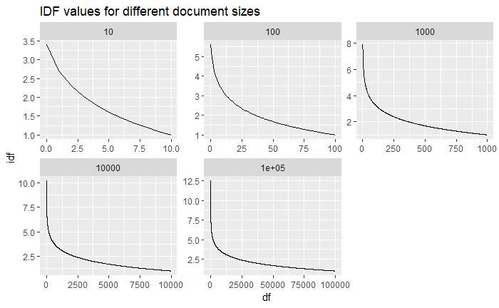

```r
bind_rows( tibble( n = 10, df = 0:10 ) %>% mutate(idf = log( (1+n)/(1+df) ) +1 )
           ,
           tibble( n = 100, df = 0:100 ) %>% mutate(idf = log( (1+n)/(1+df) ) +1 )
           ,
           tibble( n = 1000, df = 0:1000 ) %>% mutate(idf = log( (1+n)/(1+df) ) +1 )
           ,
           tibble( n = 1e4L, df = 0:1e4L ) %>% mutate(idf = log( (1+n)/(1+df) ) +1 )
           ,
           tibble( n = 1e5L, df = 0:1e5L ) %>% mutate(idf = log( (1+n)/(1+df) ) +1 )
         ) %>%
  ggplot( data = .,
          aes( x = df,
               y = idf
              )
        ) +
  geom_line() +
  facet_wrap( ~n, scales = "free" ) +
  labs( title = "IDF values for different document sizes")
```

# other useful text tools

```r
library(tidyverse)
library(tidytext)
library(janeaustenr)
library(stringr)
library(SnowballC) # for the function wordStem() for  stemming words

text <- c("Because I could not stop for Death -",
          "He kindly stopped for me -",
          "The Carriage held but just Ourselves -",
          "and Immortality"
        )

text_df <- tibble(line = 1:4, text = text)

text_df
```

| line | text |
| --- | --- |
| 1 | Because I could not stop for Death - |
| 2 | He kindly stopped for me - |
| 3 | The Carriage held but just Ourselves - |
| 4 | and Immortality |

```r
# tokenize our text dataframe:
# a 'token' is a meaningful unit of text (e.g. a word)
text_df %>%
  unnest_tokens( output = "word",     # name of output column
                 input = "text",      # name of column containing the text to be tokenized
                 to_lower = TRUE,     # convert text to lowercase
                 strip_punct = TRUE  # remove punctuation (.,-/ etc.)
               )
```

| line | word |
| --- | --- |
| 1 | because |
| 1 | i |
| 1 | could |
| 1 | not |
| 1 | stop |
| 1 | for |
| 1 | death |
| 2 | he |
| 2 | kindly |
| 2 | stopped |

[output cut: 10 more lines]

```r
raw_books <- austen_books()

raw_books %>% slice(500:510)
```

| text | book |
| --- | --- |
| a lover, not as a connoisseur. To satisfy me, those characters must be | Sense & Sensibility |
| united. I could not be happy with a man whose taste did not in every | Sense & Sensibility |
| point coincide with my own. He must enter into all my feelings; the | Sense & Sensibility |
| same books, the same music must charm us both. Oh! mama, how | Sense & Sensibility |
| spiritless, how tame was Edward's manner in reading to us last night! | Sense & Sensibility |
| I felt for my sister most severely. Yet she bore it with so much | Sense & Sensibility |
| composure, she seemed scarcely to notice it. I could hardly keep my | Sense & Sensibility |
| seat. To hear those beautiful lines which have frequently almost | Sense & Sensibility |
| driven me wild, pronounced with such impenetrable calmness, such | Sense & Sensibility |
| dreadful indifference!" | Sense & Sensibility |

[output cut: 1 more lines]

```r
original_books <-
  raw_books %>%
    group_by(book) %>%
      # within each book:
      mutate( # add a unique line number to each line:
              linenumber = row_number(),

              # add a chapter column by getting the chapter number out of the raw text
              chapter = cumsum(str_detect(text, regex("^chapter [\\divxlc]",
                                                     ignore_case = TRUE
                                                     )
                                          )
                               )
              ) %>%
      ungroup()

# look at a random few lines from different books:
original_books %>% sample_n(10)
```

| text | book | linenumber | chapter |
| --- | --- | --- | --- |
| were come to Bath for a few days with Mrs Musgrove, and were at the | Persuasion | 7089 | 22 |
| mistaken in his opinion of their circumstances and character, misled by | Northanger Abbey | 7667 | 30 |
| of the gardens, where no damps from the river were imagined even by him, | Emma | 12072 | 42 |
| sprang from these words. Could it be possible? Could Henry's father--? | Northanger Abbey | 5768 | 23 |
| some of the gentlemen at Pemberley before noon. | Pride & Prejudice | 8772 | 44 |
| and handsome; and the Middletons lived in a style of equal hospitality | Sense & Sensibility | 961 | 7 |
| as to make them for a while each other's punishment, and then induce a | Mansfield Park | 15037 | 48 |
| door--and the moment she was gone, this was the spontaneous burst of | Emma | 13791 | 47 |
|  | Northanger Abbey | 3837 | 15 |
| estranged from each other." | Sense & Sensibility | 5072 | 25 |

```r
# put into tidy text format:
tidy_books <-
  original_books %>%
    unnest_tokens(input="text", output="word")

tidy_books %>%  head(20)
```

| book | linenumber | chapter | word |
| --- | --- | --- | --- |
| Sense & Sensibility | 1 | 0 | sense |
| Sense & Sensibility | 1 | 0 | and |
| Sense & Sensibility | 1 | 0 | sensibility |
| Sense & Sensibility | 3 | 0 | by |
| Sense & Sensibility | 3 | 0 | jane |
| Sense & Sensibility | 3 | 0 | austen |
| Sense & Sensibility | 5 | 0 | 1811 |
| Sense & Sensibility | 10 | 1 | chapter |
| Sense & Sensibility | 10 | 1 | 1 |
| Sense & Sensibility | 13 | 1 | the |

[output cut: 10 more lines]

```r
# get a list of stop-words (words not useful in analysis, like 'the', 'of', 'to' etc.)
data(stop_words)

nrow(stop_words)
```

```
[1] 1149
```

```r
head(stop_words, 20)
```

| word | lexicon |
| --- | --- |
| a | SMART |
| a's | SMART |
| able | SMART |
| about | SMART |
| above | SMART |
| according | SMART |
| accordingly | SMART |
| across | SMART |
| actually | SMART |
| after | SMART |

[output cut: 10 more lines]

```r
tidy_books_no_stopwords <-
  tidy_books %>%
    anti_join(stop_words)
tidy_books %>% head(20)
```

| book | linenumber | chapter | word |
| --- | --- | --- | --- |
| Sense & Sensibility | 1 | 0 | sense |
| Sense & Sensibility | 1 | 0 | and |
| Sense & Sensibility | 1 | 0 | sensibility |
| Sense & Sensibility | 3 | 0 | by |
| Sense & Sensibility | 3 | 0 | jane |
| Sense & Sensibility | 3 | 0 | austen |
| Sense & Sensibility | 5 | 0 | 1811 |
| Sense & Sensibility | 10 | 1 | chapter |
| Sense & Sensibility | 10 | 1 | 1 |
| Sense & Sensibility | 13 | 1 | the |

[output cut: 10 more lines]

```r
tidy_books_no_stopwords %>% head(20)
```

| book | linenumber | chapter | word |
| --- | --- | --- | --- |
| Sense & Sensibility | 1 | 0 | sense |
| Sense & Sensibility | 1 | 0 | sensibility |
| Sense & Sensibility | 3 | 0 | jane |
| Sense & Sensibility | 3 | 0 | austen |
| Sense & Sensibility | 5 | 0 | 1811 |
| Sense & Sensibility | 10 | 1 | chapter |
| Sense & Sensibility | 10 | 1 | 1 |
| Sense & Sensibility | 13 | 1 | family |
| Sense & Sensibility | 13 | 1 | dashwood |
| Sense & Sensibility | 13 | 1 | settled |

[output cut: 10 more lines]

```r
# count most common words across all books:
tidy_books_no_stopwords %>%
  count( word, sort=TRUE ) %>%
  head(20)
```

| word | n |
| --- | --- |
| miss | 1855 |
| time | 1337 |
| fanny | 862 |
| dear | 822 |
| lady | 817 |
| sir | 806 |
| day | 797 |
| emma | 787 |
| sister | 727 |
| house | 699 |

[output cut: 10 more lines]

```r
?str_extract
# We use str_extract() here because the UTF-8 encoded texts from Project
# Gutenberg have some examples of words with underscores around them to indicate
# emphasis (like italics). The tokenizer treated these as words, but we don't want
# to count "_any_" separately from "any" as we saw in our initial data
# exploration before choosing to use str_extract()
# go search for this text in https://www.tidytextmining.com/tidytext.html

tibble( word = c("word", "_word_", "%w%o%r%d%") ) %>%
  mutate( word_clean1 = str_extract(word, "[a-z']+"),
          word_clean2 = str_remove_all( word, "\\W+" )
        )
```

| word | word_clean1 | word_clean2 |
| --- | --- | --- |
| word | word | word |
| _word_ | word | _word_ |
| %w%o%r%d% | w | word |

```r
# checking out tf-idf:
example_dat <- tibble( document = paste("document", 1:5, sep="_"),
                       document_text = c( "black and big black boots and black",
                                          "black pants formal and with buttons",
                                          "BIG black and red pants with big buttons",
                                          "black hat with red and green stripes",
                                          "blue formal waistcoat"
                                        )
                       )

get_tf.idf <-
example_dat %>%
  unnest_tokens( input="document_text", output="word" ) %>%
  group_by( document, word ) %>%
  summarise( n_times_in_doc = n() ) %>%
  ungroup() %>%
  group_by( word ) %>%
  mutate( n_docs_containing_word = n_distinct(document) ) %>%
  group_by( document ) %>%
  mutate( n_words_in_doc = sum(n_times_in_doc) ) %>%
  ungroup() %>%
  mutate( joe_tf = n_times_in_doc / n_words_in_doc ) %>%
  ungroup() %>%
  mutate( `n_docs/n_docs_containing_word` = 5 / n_docs_containing_word ) %>%
  mutate( joe_idf = log(`n_docs/n_docs_containing_word`) ) %>%
  mutate( joe_tf_idf = joe_tf * joe_idf ) %>%
  bind_tf_idf( tbl =.,
               term = word,
               document = document,
               n = n_times_in_doc
  ) %>%
  arrange( document, desc(tf_idf) )
#
# # turn our tidy dataframe into a document-term matrix:
# example_dat %>%
#   unnest_tokens( input="document_text", output="word" ) %>%
#   group_by( document, word ) %>%
#   summarise( n_times_in_doc = n() ) %>%
#   ungroup() %>%
#   cast_dtm( term = word,
#             document = document
#           )

# checking out stemming:
tibble( unstemmed_word = c("running", "run", "runs", "runned", "runner", "runners", "ran") ) %>%
  mutate( stemmed_word = map_chr( .x = unstemmed_word,
                                .f = function(word){ wordStem( word, language="en" ) }
                                )
  )
```

| unstemmed_word | stemmed_word |
| --- | --- |
| running | run |
| run | run |
| runs | run |
| runned | run |
| runner | runner |
| runners | runner |
| ran | ran |

```r
# check out document term matrix:
```